# CS 422

Xingli Li, Illinois Institute of Technology

## Homework 1

set work space and install dependent package.

```r
base_path <- getwd()
setwd(base_path)

# install.packages("magrittr")
# library("magrittr")

# install.packages("corrplot")
# library(corrplot)

# install.packages("dplyr")
# library("dplyr")

# install.packages("psych")
# library("psych")
```

### Part 2.1-i

Read the dataset into a R dataframe; call the dataframe ‘data.df’. Pay attention to the first seven lines of the dataset. These contain comments as indicated by the ‘#’ character in dataset file. When reading the dataset, ignore the lines that contain comments. (See the manual page for read.csv() and find out the parameter that will allow you to ignore comments.)

```r
data.df <- read.csv(file = "us-covid.csv",encoding="UTF-8", comment.char = "#")

# filter(data.df,row_number() == 1:7L)
#data.df %>% as_tibble() %>% slice(1:7)
print(head(data.df,7))
```

|  | state | level | total_cases | confirmed | probable | cases_last_7_days | case_rate_per_100K | total_deaths | confirmed_deaths |
| --- | --- | --- | --- | --- | --- | --- | --- | --- | --- |
| 1 | Alabama | high | 1172663 | 851889 | 320774 | 80296 | 23916 | 16948 | 13126 |
| 2 | Alaska | high | 194176 | 0 | 0 | 21847 | 26543 | 1039 | N/A |
| 3 | Arizona | high | 1781274 | 1588439 | 192835 | 135580 | 24472 | 25624 | 22105 |
| 4 | Arkansas | high | 749824 | 0 | 0 | 61835 | 24847 | 9556 | N/A |
| 5 | California | high | 7929436 | 7482469 | 446967 | 743850 | 20068 | 78118 | N/A |
| 6 | Colorado | high | 1215931 | 1111809 | 104122 | 69191 | 21114 | 10933 | 9650 |
| 7 | Connecticut | high | 687555 | 617027 | 70528 | 29875 | 19285 | 9773 | 7974 |

### Part 2.2-ii

```r
data.df = data.df[,-9]
#data.df[,9] <- NULL

data.df
```

| state | level | total_cases | confirmed | probable | cases_last_7_days | case_rate_per_100K | total_deaths |
| --- | --- | --- | --- | --- | --- | --- | --- |
| Alabama | high | 1172663 | 851889 | 320774 | 80296 | 23916 | 16948 |
| Alaska | high | 194176 | 0 | 0 | 21847 | 26543 | 1039 |
| Arizona | high | 1781274 | 1588439 | 192835 | 135580 | 24472 | 25624 |
| Arkansas | high | 749824 | 0 | 0 | 61835 | 24847 | 9556 |
| California | high | 7929436 | 7482469 | 446967 | 743850 | 20068 | 78118 |
| Colorado | high | 1215931 | 1111809 | 104122 | 69191 | 21114 | 10933 |
| Connecticut | high | 687555 | 617027 | 70528 | 29875 | 19285 | 9773 |
| Delaware | high | 242324 | 221181 | 21143 | 11448 | 24885 | 2489 |
| District of Columbia | high | 128739 | 0 | 0 | 3032 | 18242 | 1278 |
| Florida | high | 5420755 | 0 | 0 | 224996 | 25239 | 64007 |

[output cut: 42 more lines]

### Part 2.2-iii

Sort the dataframe:

```r
# by column name order
data.df.ordered <- data.df[order(data.df$total_cases),]

# by column index order
# data.df.ordered <- data.df[order(data.df[,3]),]
# data.df.ordered <- arrange(data.df,data.df[,3])

#print(head(data.df.ordered,6))
#print(tail(data.df.ordered,6))

print(data.df.ordered[1:6,])
```

|  | state | level | total_cases | confirmed | probable | cases_last_7_days | case_rate_per_100K | total_deaths |
| --- | --- | --- | --- | --- | --- | --- | --- | --- |
| 47 | Vermont | high | 92563 | 0 | 0 | 7446 | 14834 | 498 |
| 9 | District of Columbia | high | 128739 | 0 | 0 | 3032 | 18242 | 1278 |
| 52 | Wyoming | high | 139461 | 109726 | 29735 | 8908 | 24097 | 1625 |
| 20 | Maine | high | 169997 | 124857 | 45140 | 7056 | 12647 | 1716 |
| 2 | Alaska | high | 194176 | 0 | 0 | 21847 | 26543 | 1039 |
| 12 | Hawaii | high | 202064 | 0 | 0 | 25625 | 14271 | 1135 |

```r
print(data.df.ordered[(nrow(data.df.ordered)-5):nrow(data.df.ordered),])
```

|  | state | level | total_cases | confirmed | probable | cases_last_7_days | case_rate_per_100K | total_deaths |
| --- | --- | --- | --- | --- | --- | --- | --- | --- |
| 36 | Ohio | high | 2520112 | 1964622 | 555490 | 101320 | 21560 | 32489 |
| 39 | Pennsylvania | high | 2592691 | 2147222 | 445469 | 104766 | 20252 | 39749 |
| 14 | Illinois | high | 2851567 | 2851567 | 0 | 168584 | 22503 | 33942 |
| 10 | Florida | high | 5420755 | 0 | 0 | 224996 | 25239 | 64007 |
| 45 | Texas | high | 6018220 | 0 | 0 | 373823 | 20755 | 77058 |
| 5 | California | high | 7929436 | 7482469 | 446967 | 743850 | 20068 | 78118 |

### Part 2.2-iv

Create a correlation visualization using the pairs.panels() API from the R library psych. Note that the first two columns can be excluded from correlation analysis. Plot the correlation and use it to answer the following questions:

1. Why should we exclude the first two columns from correlation analysis?

   ```
   First, neither of the first twon columns are computable data types.
   Then, the "state" column represent entity, the "level" column of each entity is same value, which is pointless.
   ```

2. Which pair of columns have the highest correlation?

   ```
   The "total_cases" and "total_deaths" column have the highest correlation.
   ```

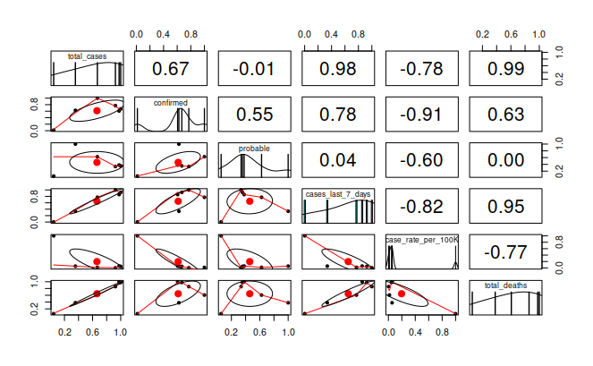

```r
data.df.selected <- data.df[,3:ncol(data.df)]

ress <- cor(data.df.selected)

# Create a correlation visualization.#
pairs.panels(ress)
```

### Part 2.2-v

Focus on confirmed cases, probable cases, and total deaths.

1. Draw a plot of confirmed+probable cases (on the X-axis) against the total deaths (on the Y-axis). Label the plot appropriately.
2. As you see the plot, there appears to be an anomaly. Looking at the data, briefly describe the anomaly.
3. Print out the state name, total deaths, confirmed cases, probable cases and total cases of all such states that show this anomaly.

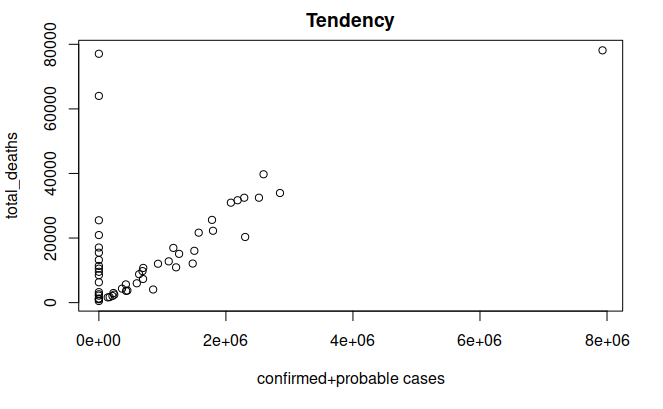

```r
new_table <- data.frame(
    cases = data.df.selected["confirmed"] + data.df.selected["probable"],
    total_deaths = data.df.selected["total_deaths"])

plot.default(new_table,type = "p",
             main = "Tendency",
             xlab = "confirmed+probable cases",
             ylab = "total_deaths")
```

```
Answer to the b question:

  The confirmed + probable cases number is zero, but total deaths number is not zero, which is unreasonable.
```

```r
# filter anomaly data
data_filtered_anom <- data.df[data.df$confirmed < data.df$total_deaths |
                              (data.df$confirmed + data.df$probable) < data.df$total_deaths |
                              data.df$total_cases < data.df$total_deaths,]

print(data_filtered_anom[c("state","confirmed","probable","total_deaths","total_cases")])
```

|  | state | confirmed | probable | total_deaths | total_cases |
| --- | --- | --- | --- | --- | --- |
| 2 | Alaska | 0 | 0 | 1039 | 194176 |
| 4 | Arkansas | 0 | 0 | 9556 | 749824 |
| 9 | District of Columbia | 0 | 0 | 1278 | 128739 |
| 10 | Florida | 0 | 0 | 64007 | 5420755 |
| 12 | Hawaii | 0 | 0 | 1135 | 202064 |
| 15 | Indiana | 0 | 0 | 20928 | 1569850 |
| 16 | Iowa | 0 | 0 | 8501 | 699859 |
| 19 | Louisiana | 0 | 0 | 15476 | 1084448 |
| 21 | Maryland | 0 | 0 | 13233 | 940713 |
| 24 | Minnesota | 0 | 0 | 11370 | 1264935 |

[output cut: 9 more lines]

```r
NA
```